# Лабораторная работа № 6

Модель SIR с использованием сетей Петри

Талебу Тенке Франк

2026-11-01

# Информация

## Докладчик

- **Талебу Тенке Франк**
- **Студенческий билет:** 1032224534
- Российский университет дружбы народов имени Патриса Лумумбы
- Дисциплина: Имитационное моделирование
- Лабораторная работа № 6

# Вводная часть

## Актуальность

- Модель SIR описывает распространение инфекции в популяции.
- Сети Петри позволяют наглядно представить состояния и переходы между ними.
- Сравнение детерминированного и стохастического подходов помогает оценить влияние случайности.

## Объект и предмет исследования

- **Объект:** распространение инфекционного заболевания в популяции.
- **Предмет:** переходы между группами восприимчивых, инфицированных и выздоровевших, а также влияние коэффициента заражения β.

## Цели и задачи

**Цель:** реализовать и исследовать модель SIR на основе сетей Петри в Julia.

- Создать и запустить код модели.
- Выполнить базовый детерминированный и стохастический прогоны.
- Исследовать влияние коэффициента заражения β.
- Подготовить сравнительные графики и итоговый анализ.

## Материалы и методы

- **Julia:** реализация и запуск вычислительных экспериментов.
- **Сети Петри:** состояния S, I, R и переходы заражения и выздоровления.
- **DrWatson:** организация проекта и путей к файлам.
- **Jupyter и Quarto:** выполнение, документирование и представление результатов.

## выполнение

[figure not shown]

## выполнение

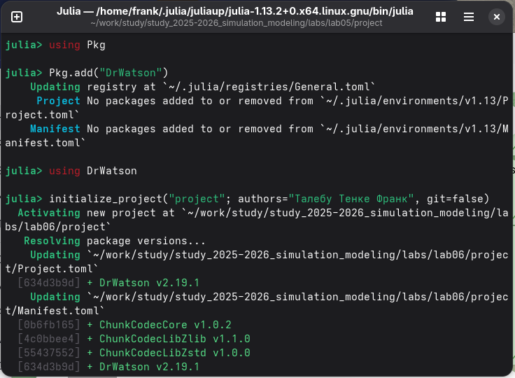

## выполнение

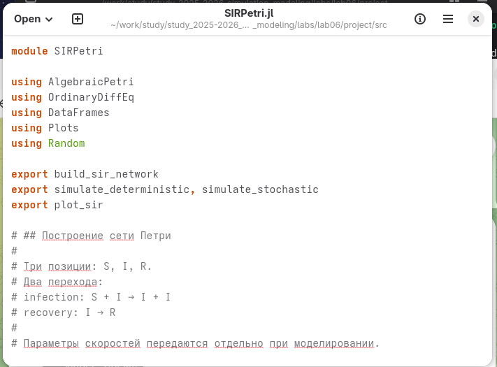

## выполнение

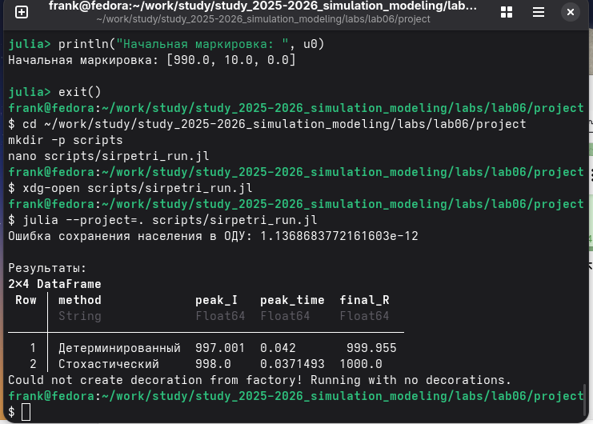

## выполнение

[figure not shown]

## выполнение

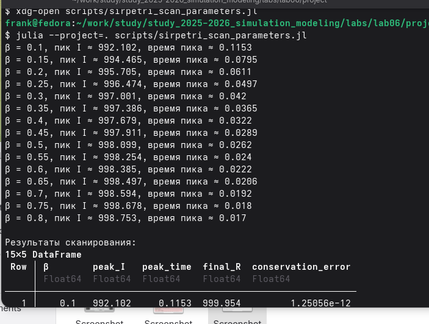

## выполнение

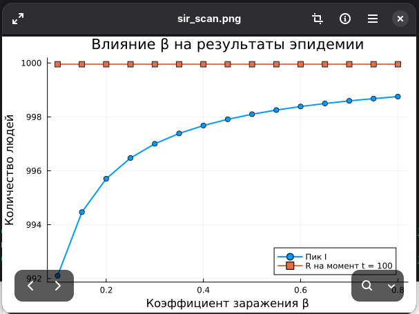

## выполнение

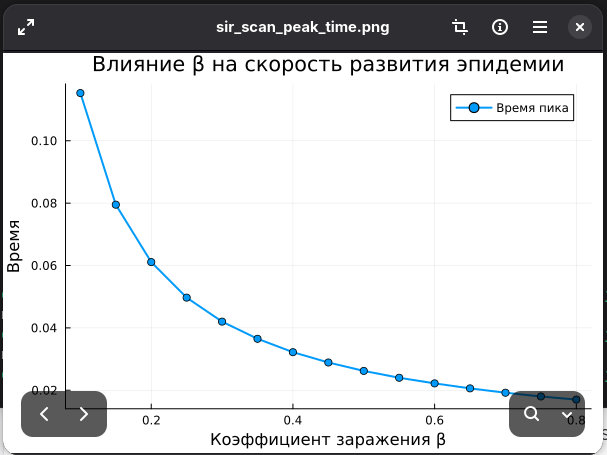

## выполнение

[figure not shown]

## выполнение

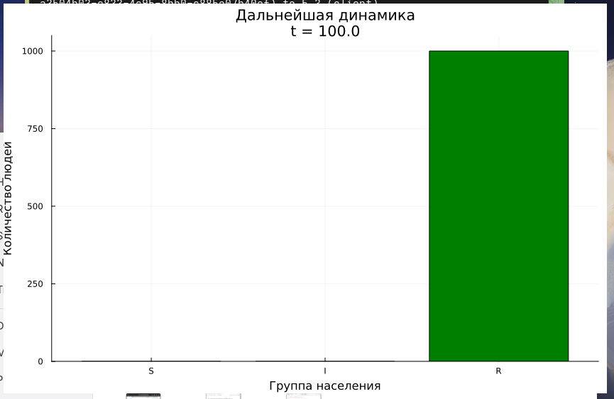

## выполнение

[figure not shown]

## выполнение

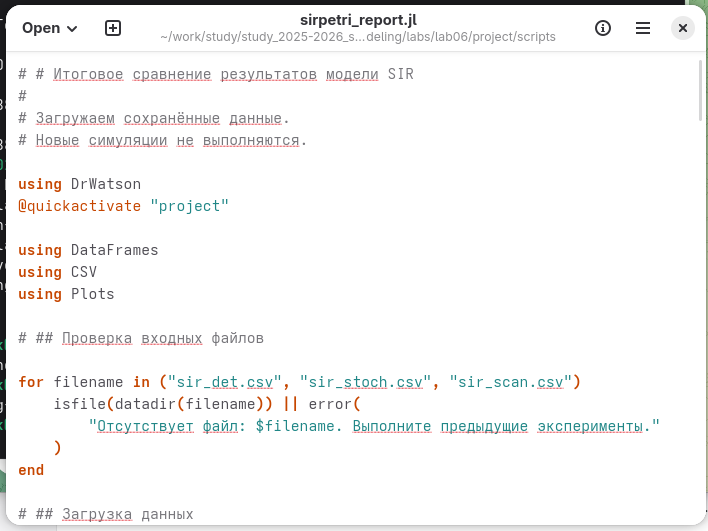

## выполнение

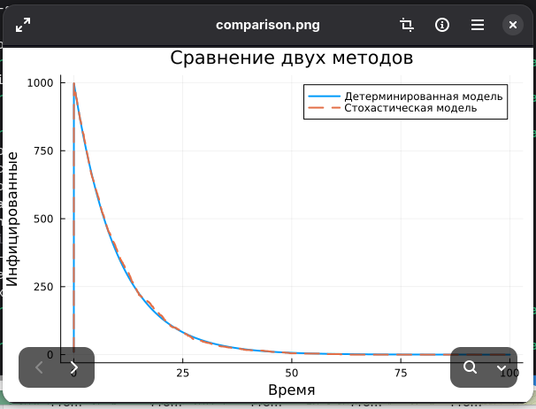

## выполнение

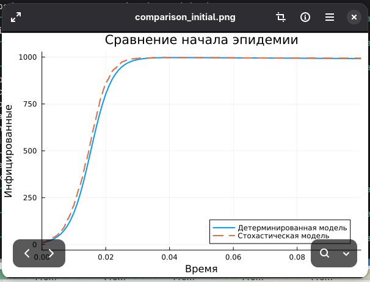

## выполнение

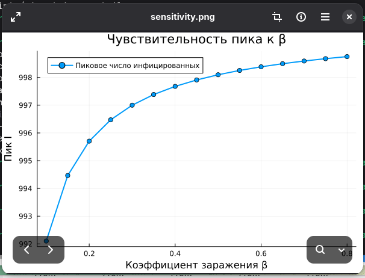

## выполнение

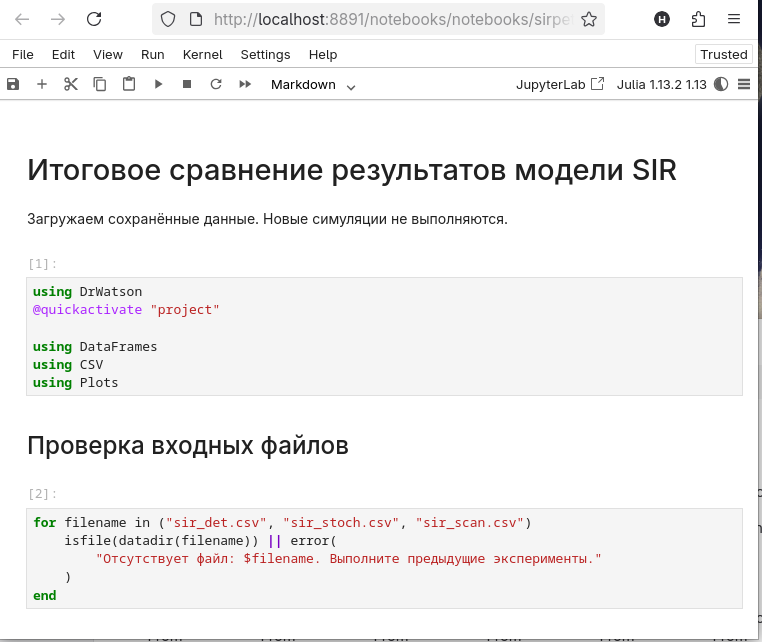

# Результаты и обсуждение

## Основные результаты

- Реализована модель SIR с использованием сетей Петри.
- Выполнены детерминированный и стохастический прогоны.
- Проведено исследование изменения коэффициента заражения β.
- Подготовлены сравнительные графики для итогового отчёта.

# Заключение

## Выводы

- Сети Петри позволяют описать переходы между эпидемиологическими состояниями.
- Детерминированное моделирование показывает ожидаемую динамику, а стохастическое — возможные отклонения.
- Изменение β позволяет исследовать чувствительность пика заболеваемости и общего масштаба эпидемии.

## Спасибо за внимание!